# Legends

Author

JB

# 1 Basic Box Plot

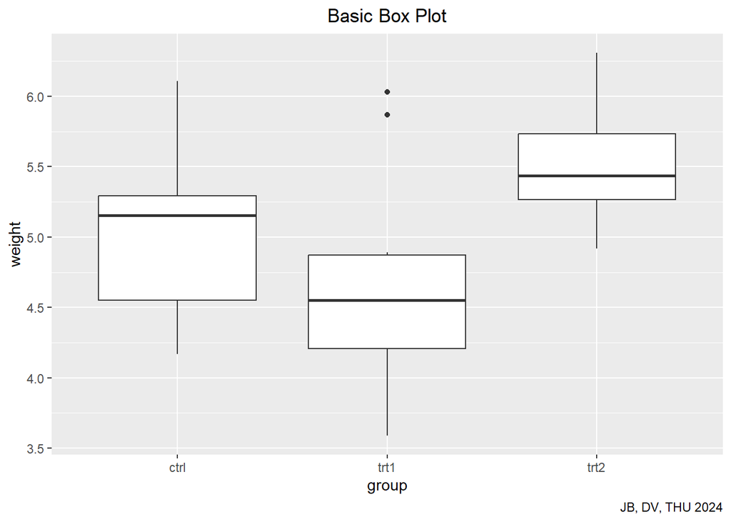

```r
library(ggplot2)
ggplot(PlantGrowth, aes(x = group, y = weight)) +
  geom_boxplot() +
  labs(title = 'Basic Box Plot', caption = 'JB, DV, THU 2024') +
  theme(plot.title = element_text(hjust=0.5))
```

# 2 Add Legend

By adding `fill` or `color` options to `aes()`, a legend is created automatically on the right side of the plot.

- `library(gridExtra)`: This loads the `gridExtra` library to use `grid.arrange`
- `fill`: Fill in the `colors` inside the chart
- `color`: Change the `color` of the outlines of the chart
- `grid.arrange`: Arrange the order of the chart
- `top`: Add `text` on the top of the chart
- `bottom`: Add `text` on the bottom of the chart

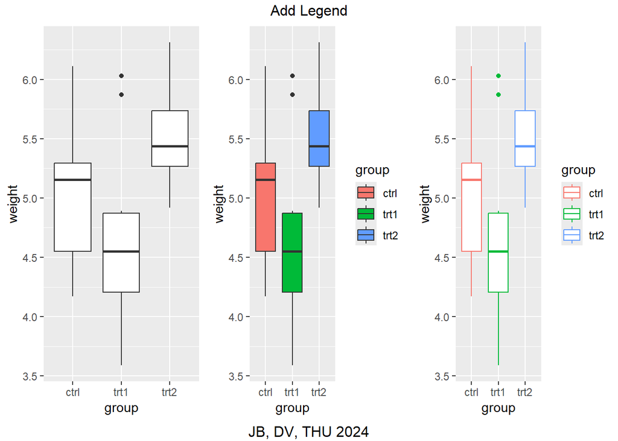

```r
library(gridExtra)

p1 <- ggplot(PlantGrowth, aes(x = group, y = weight)) +
  geom_boxplot()
p2 <- ggplot(PlantGrowth, aes(x = group, y = weight, fill = group)) +
  geom_boxplot()
p3 <- ggplot(PlantGrowth, aes(x = group, y = weight, color = group)) +
  geom_boxplot()
grid.arrange(p1,p2,p3,ncol=3,top='Add Legend', bottom = 'JB, DV, THU 2024')
```

# 3 Remove Legend

The legend is removed by `guides(fill = FALSE)`

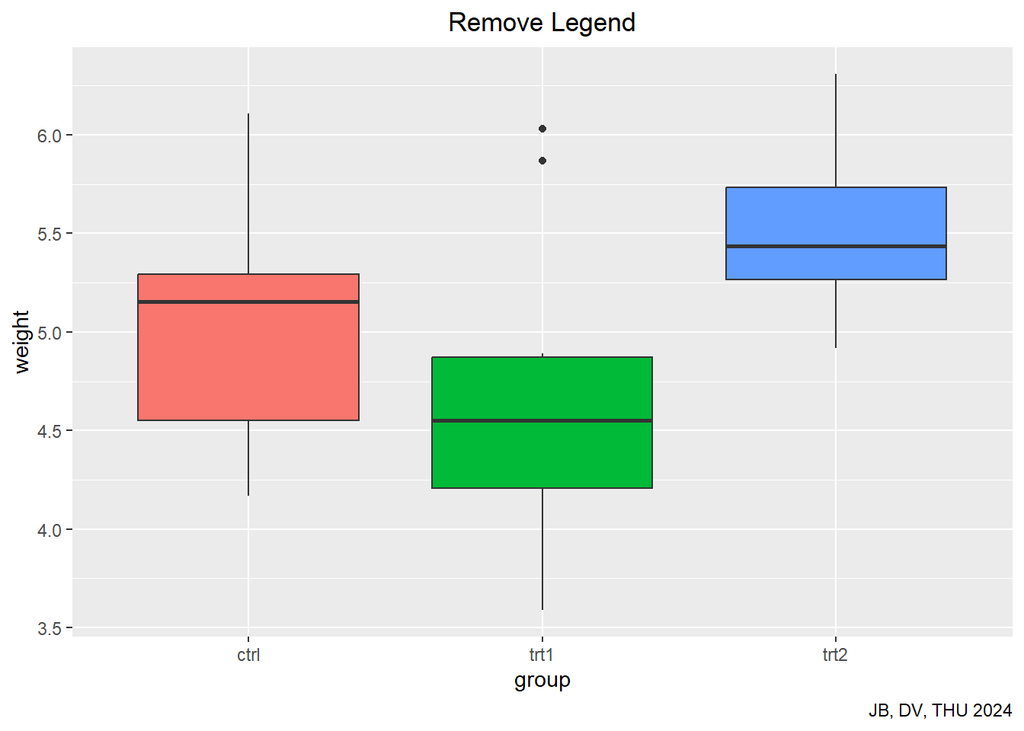

```r
ggplot(PlantGrowth, aes(x = group, y = weight, fill = group)) +
  geom_boxplot() +
  guides(fill = FALSE) +
  ggtitle('Remove Legend') +
  labs(caption = 'JB, DV, THU 2024') +
  theme(plot.title = element_text(hjust=0.5))
```

# 4 Change Color of Legend

`scale_fill_brewer(palette = "Pastel2")` is used to change the color of the legend

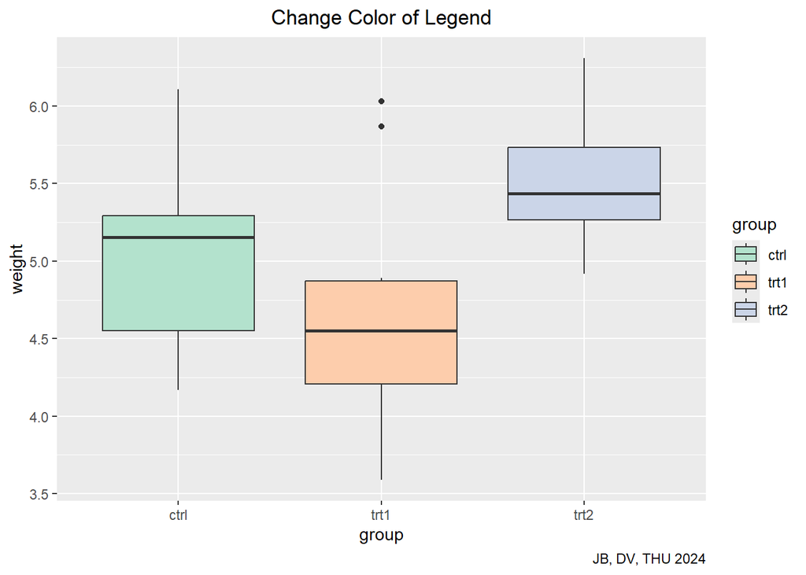

```r
ggplot(PlantGrowth, aes(x = group, y = weight, fill = group)) +
  geom_boxplot() +
  scale_fill_brewer(palette = "Pastel2") +
  ggtitle('Change Color of Legend') +
  labs(caption = 'JB, DV, THU 2024') +
  theme(plot.title = element_text(hjust=0.5))
```

# 5 Change Position of Legend

`legend.postion` in `theme` is used to change the position of the legend

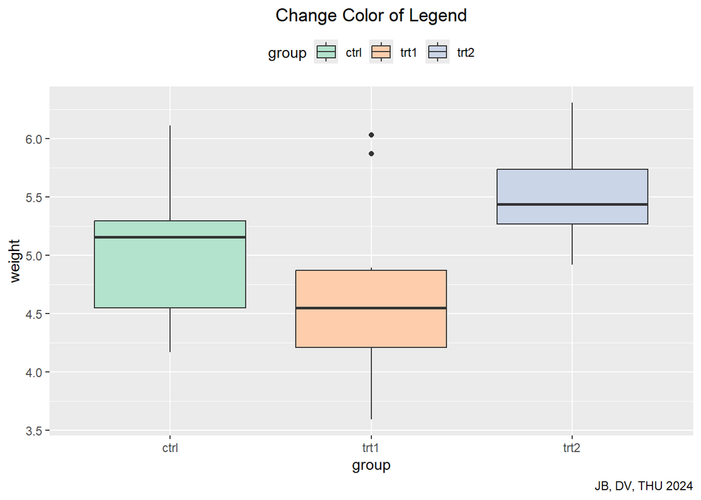

```r
ggplot(PlantGrowth, aes(x = group, y = weight, fill = group)) +
  geom_boxplot() +
  scale_fill_brewer(palette = "Pastel2") +
  ggtitle('Change Color of Legend') +
  labs(caption = 'JB, DV, THU 2024') +
  theme(plot.title = element_text(hjust=0.5),
        legend.position = 'top')
```

# 6 Practice

- Change legend position to top, bottom, left, and right
  - `legend.position = 'top'`: To change the position of the legend to `top`
  - `legend.position = 'bottom'`: To change the position of the legend to `bottom`
  - `legend.position = 'left'`: To change the position of the legend to `left`
  - `legend.position = 'right'`: To change the position of the legend to `right``

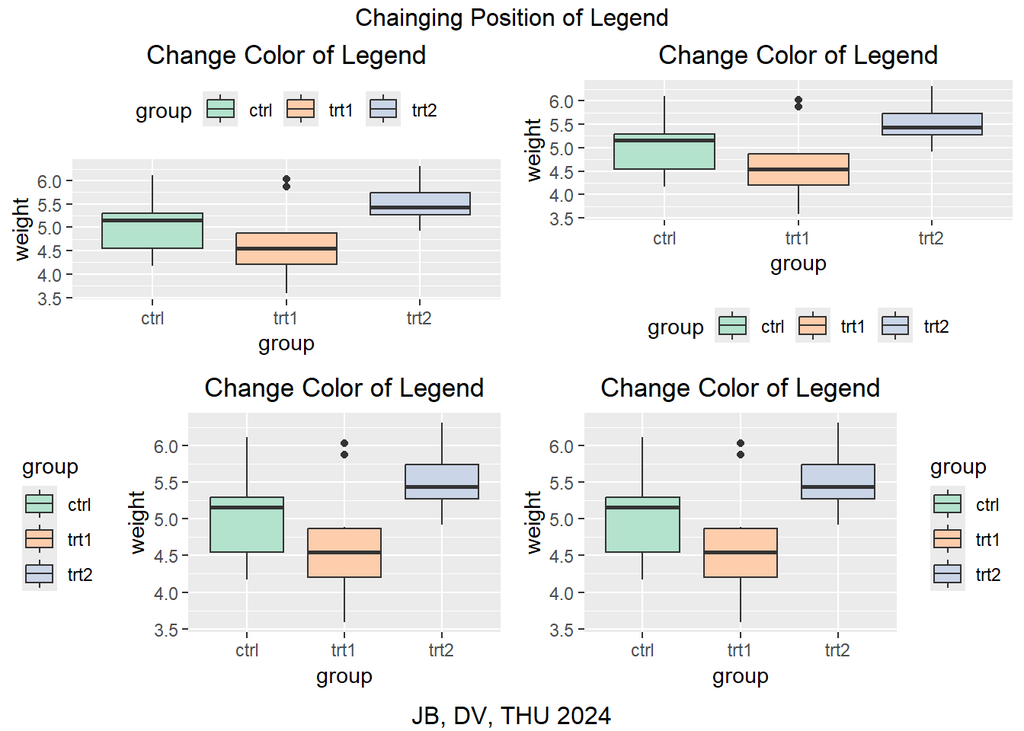

```r
p1 <- ggplot(PlantGrowth, aes(x = group, y = weight, fill = group)) +
  geom_boxplot() +
  scale_fill_brewer(palette = "Pastel2") +
  ggtitle('Change Color of Legend') +
  theme(plot.title = element_text(hjust=0.5),
        legend.position = 'top')
p2 <- p1 + theme(legend.position = 'bottom')
p3 <- p1 + theme(legend.position = 'left')
p4 <- p1 + theme(legend.position = 'right')

grid.arrange(p1, p2, p3, p4, ncol=2,
             top='Chainging Position of Legend', bottom = 'JB, DV, THU 2024')
```

# 7 Change Position of Legend

- Using the `legend.position` line we are able to change the position the legend, and using the `c(x, y)` to set the position
  - the graph below shows the legend position in `c(.9, .3)`

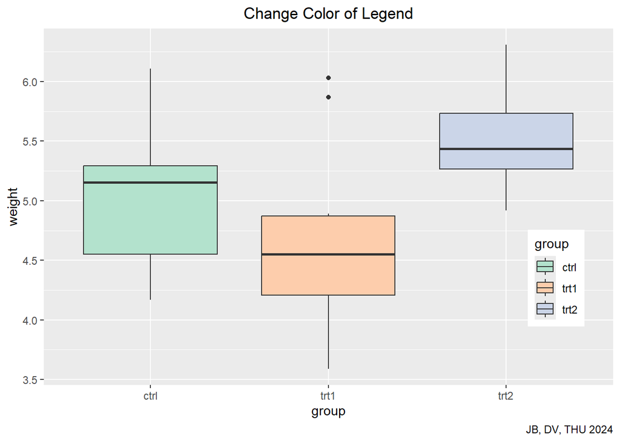

```r
ggplot(PlantGrowth, aes(x = group, y = weight, fill = group)) +
  geom_boxplot() +
  scale_fill_brewer(palette = "Pastel2") +
  ggtitle('Change Color of Legend') +
  labs(caption = 'JB, DV, THU 2024') +
  theme(plot.title = element_text(hjust=0.5),
        legend.position = c(.9, .3))
```

# 8 Change Border of Legend

Using `legend.background` line, we are able to change the `color` of the border using `color`

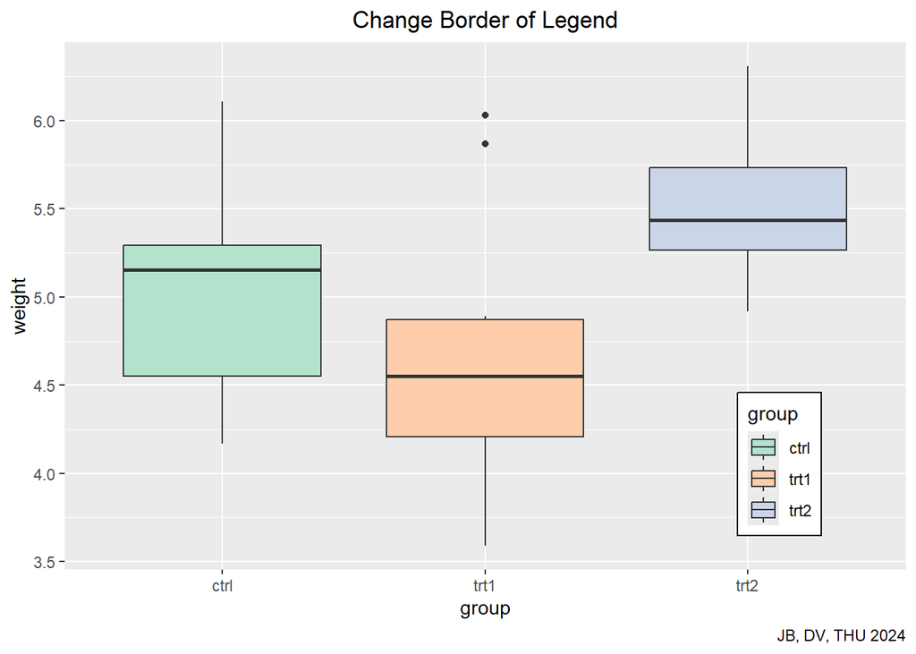

```r
ggplot(PlantGrowth, aes(x = group, y = weight, fill = group)) +
  geom_boxplot() +
  scale_fill_brewer(palette = "Pastel2") +
  ggtitle('Change Border of Legend') +
  labs(caption = 'JB, DV, THU 2024') +
  theme(plot.title = element_text(hjust=0.5),
        legend.position = c(0.85, 0.2),
        legend.background = element_rect(fill = 'white',
                                         color = 'black'))
```

# 9 Change Background of Legend

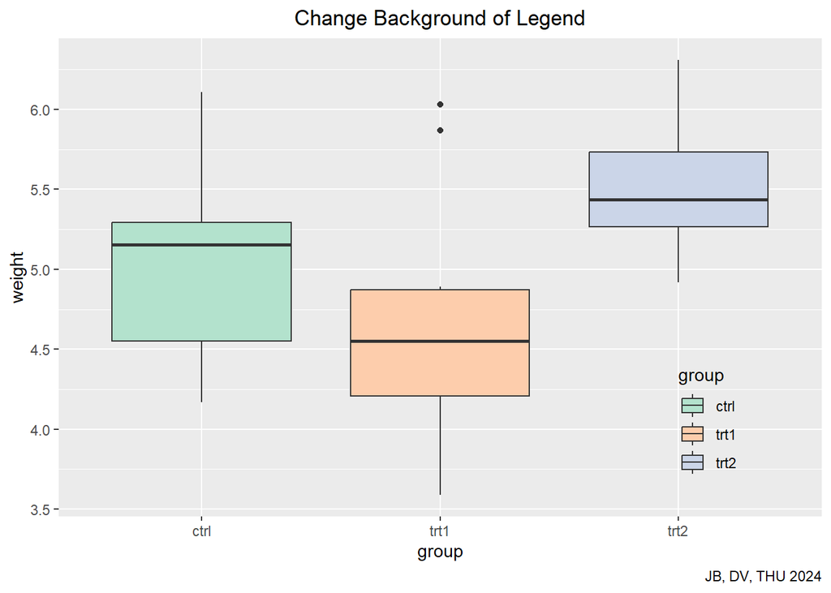

```r
ggplot(PlantGrowth, aes(x = group, y = weight, fill = group)) +
  geom_boxplot() +
  scale_fill_brewer(palette = "Pastel2") +
  ggtitle('Change Background of Legend') +
  labs(caption = 'JB, DV, THU 2024') +
  theme(plot.title = element_text(hjust=0.5),
        legend.position = c(0.85, 0.2),
        legend.background = element_blank(),
        legend.key = element_blank())
```

Optionally, we can also change the colors using the Palette provided by from `ColorBrewer` provided in the `ggplot2`. Changing the `palette` will change the color of the chart

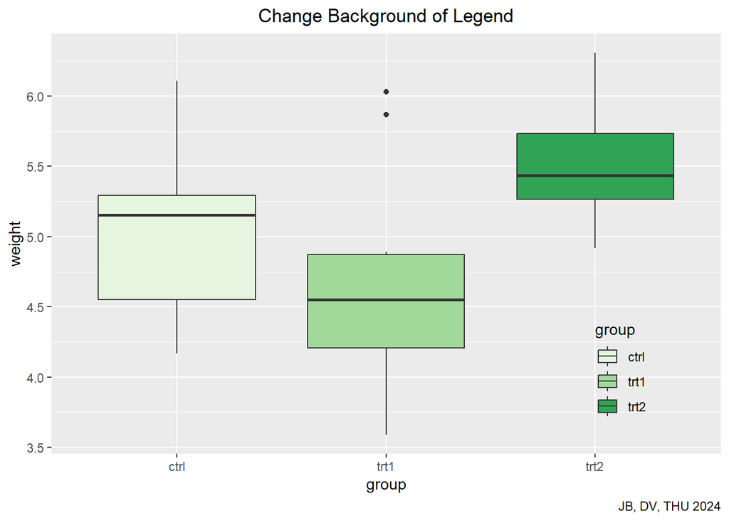

```r
ggplot(PlantGrowth, aes(x = group, y = weight, fill = group)) +
  geom_boxplot() +
  scale_fill_brewer(palette = "Pastel6") +
  ggtitle('Change Background of Legend') +
  labs(caption = 'JB, DV, THU 2024') +
  theme(plot.title = element_text(hjust=0.5),
        legend.position = c(0.85, 0.2),
        legend.background = element_blank(),
        legend.key = element_blank())
```

The `palette` provided are

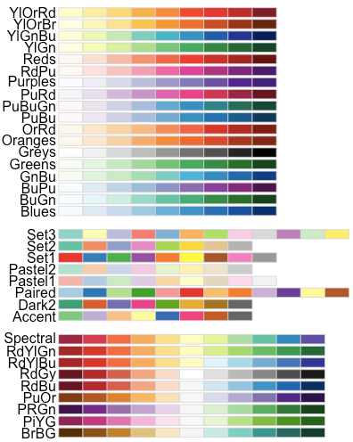

ggplot2 Palette

# 10 Change Order of Items in Legend

To change the order of the items in Legend, we can use `scale_fill_discrete` to add limits so that the items will be limited to the `order` that we want

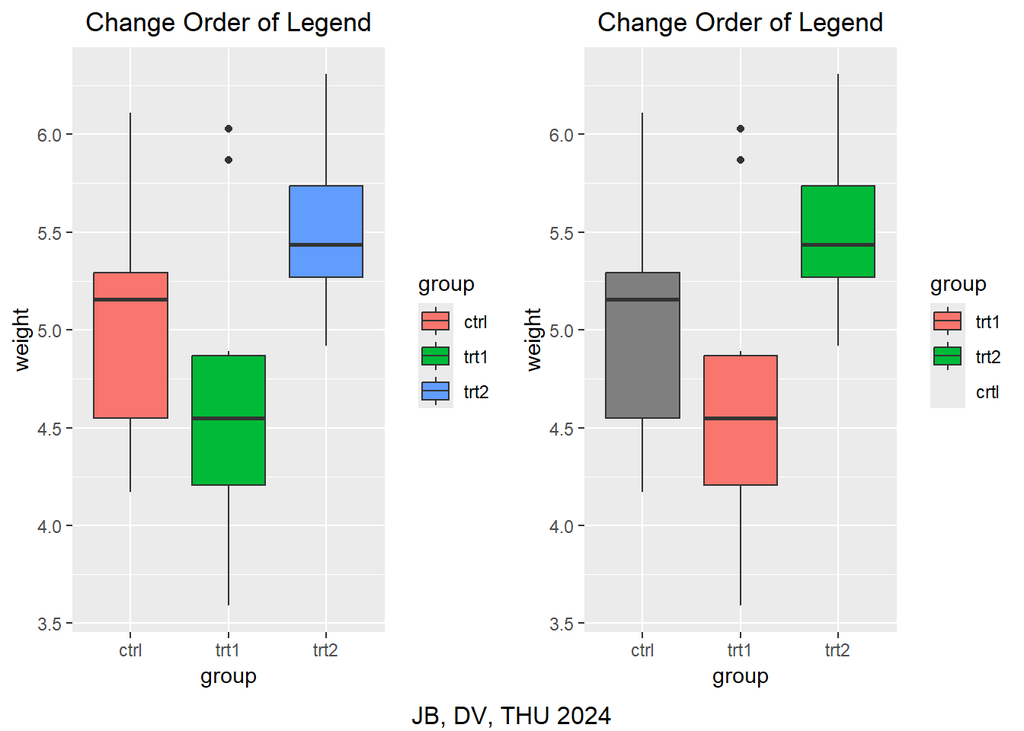

```r
p1 <- ggplot(PlantGrowth, aes(x = group, y = weight, fill = group)) +
  geom_boxplot() +
  ggtitle('Change Order of Legend') +
  theme(plot.title = element_text(hjust=0.5))

p2 <- p1 + scale_fill_discrete(limits = c('trt1', 'trt2', 'crtl'))

grid.arrange(p1, p2, ncol = 2, bottom = 'JB, DV, THU 2024')
```

# 11 Reverse Order of Items in Legend

To reverse the order of Items in Legend we use the line `guide_legend(reverse = TRUE)`

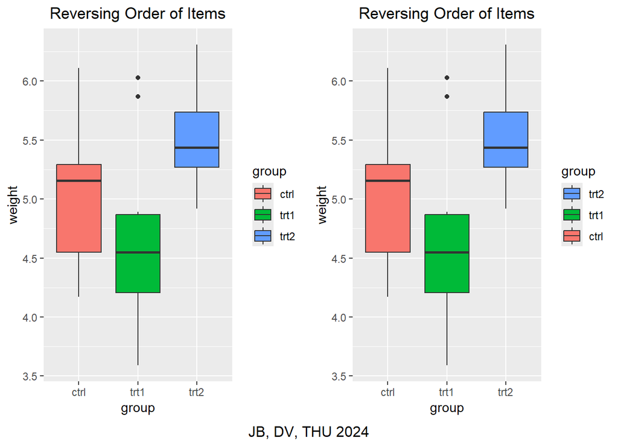

```r
p1 <- ggplot(PlantGrowth, aes(x = group, y = weight, fill = group)) +
  geom_boxplot() +
  ggtitle('Reversing Order of Items') +
  theme(plot.title = element_text(hjust=0.5))

p2 <- p1 + guides(fill = guide_legend(reverse = TRUE))

grid.arrange(p1, p2, ncol = 2, bottom = 'JB, DV, THU 2024')
```

# 12 Change Legend Title

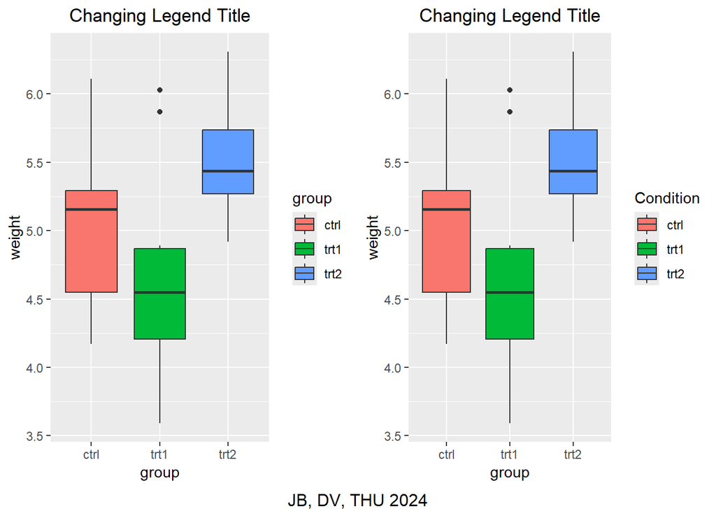

```r
p1 <- ggplot(PlantGrowth, aes(x = group, y = weight, fill = group)) +
  geom_boxplot() +
  ggtitle('Changing Legend Title') +
  theme(plot.title = element_text(hjust=0.5))

p2 <- p1 + labs(fill = 'Condition')

grid.arrange(p1, p2, ncol = 2, bottom = 'JB, DV, THU 2024')
```

# 13 Change Appearance of Legend Title

- To change the appearance, we can add `legend.title` in the `theme` section and change the following:
  - `face`: To change style of the text (`bold`, `italic`, `underline`)
  - `family`: To change the Font Style
  - `color`: To change the `color` of the text
  - `size`: To change the `size` of the text

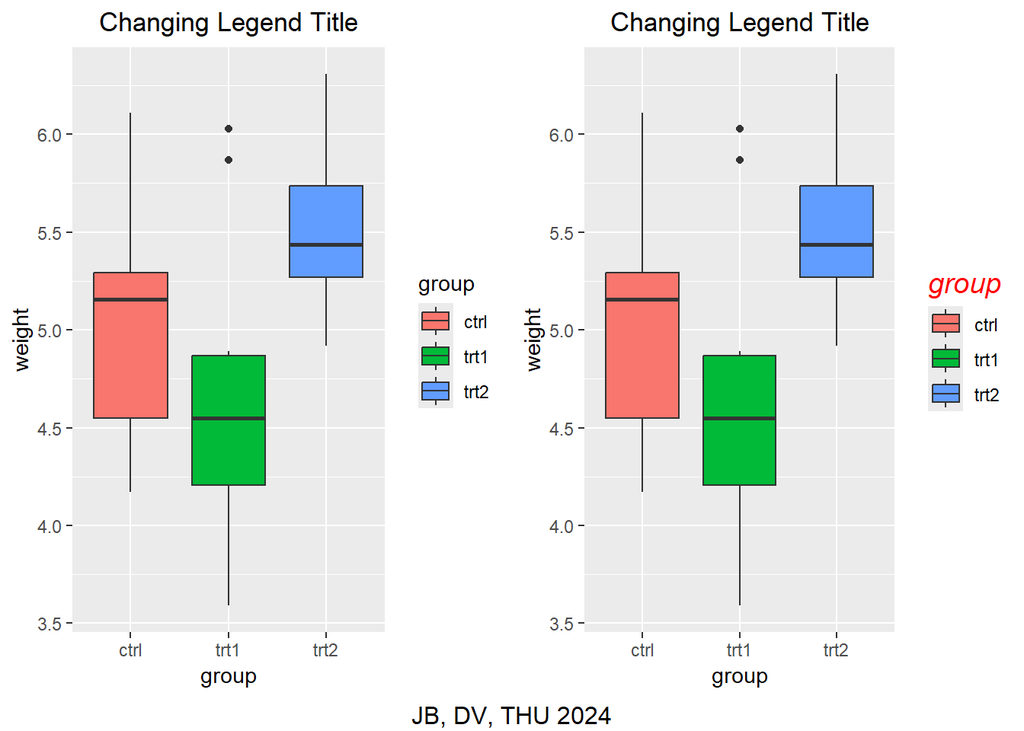

```r
p1 <- ggplot(PlantGrowth, aes(x = group, y = weight, fill = group)) +
  geom_boxplot() +
  ggtitle('Changing Legend Title') +
  theme(plot.title = element_text(hjust=0.5))

p2 <- p1 + theme(legend.title = element_text(face = 'italic',
                                             family = 'Times',
                                             color = 'red',
                                             size = 14))
grid.arrange(p1, p2, ncol = 2, bottom = 'JB, DV, THU 2024')
```

# 14 Remove Legend Title

`guide_legend(title = NULL` is used to remove the Legend Title

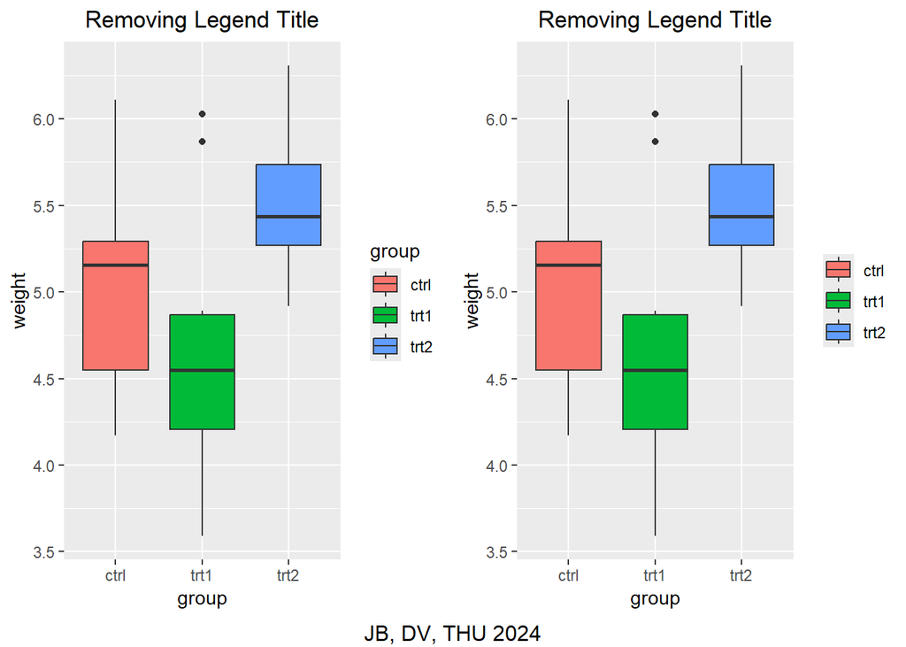

```r
p1 <- ggplot(PlantGrowth, aes(x = group, y = weight, fill = group)) +
  geom_boxplot() +
  ggtitle('Removing Legend Title') +
  theme(plot.title = element_text(hjust=0.5))

p2 <- p1 + guides(fill = guide_legend(title = NULL))

grid.arrange(p1, p2, ncol = 2, bottom = 'JB, DV, THU 2024')
```

# 15 Change Labels in Legend

To change the Labels in the Legend, we first have to make the dataset using the `c('Legend 1', 'Legend 2', 'Legend 3')` line. Next, we can use `scale_fill_discrete(labels = c(x,y,z)` to change the labels inside the legend

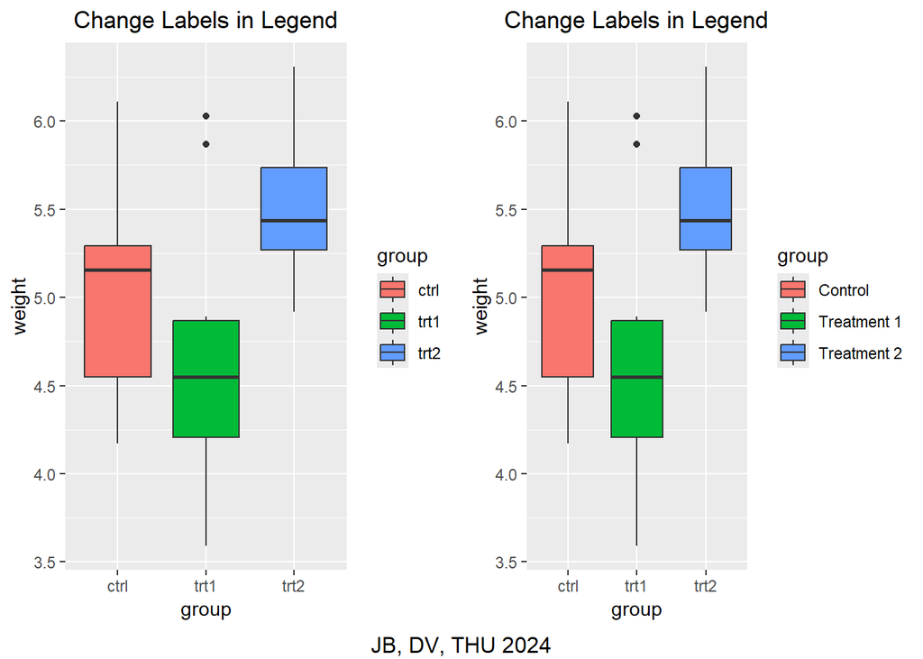

```r
p1 <- ggplot(PlantGrowth, aes(x = group, y = weight, fill = group)) +
  geom_boxplot() +
  ggtitle('Change Labels in Legend') +
  theme(plot.title = element_text(hjust=0.5))

p2 <- p1 +
  scale_fill_discrete(labels = c('Control',
                                 'Treatment 1',
                                 'Treatment 2'))

grid.arrange(p1, p2, ncol = 2, bottom = 'JB, DV, THU 2024')
```

# 16 Change Apperarence of Legend Label

- Similarly to changing the appearance of the Legend Title, we use `theme` to change the appearance, with the additional line of `legend.text`
  - `face`: To change style of the text (`bold`, `italic`, `underline`)
  - `family`: To change the Font Style
  - `color`: To change the `color` of the text
  - `size`: To change the `size` of the text

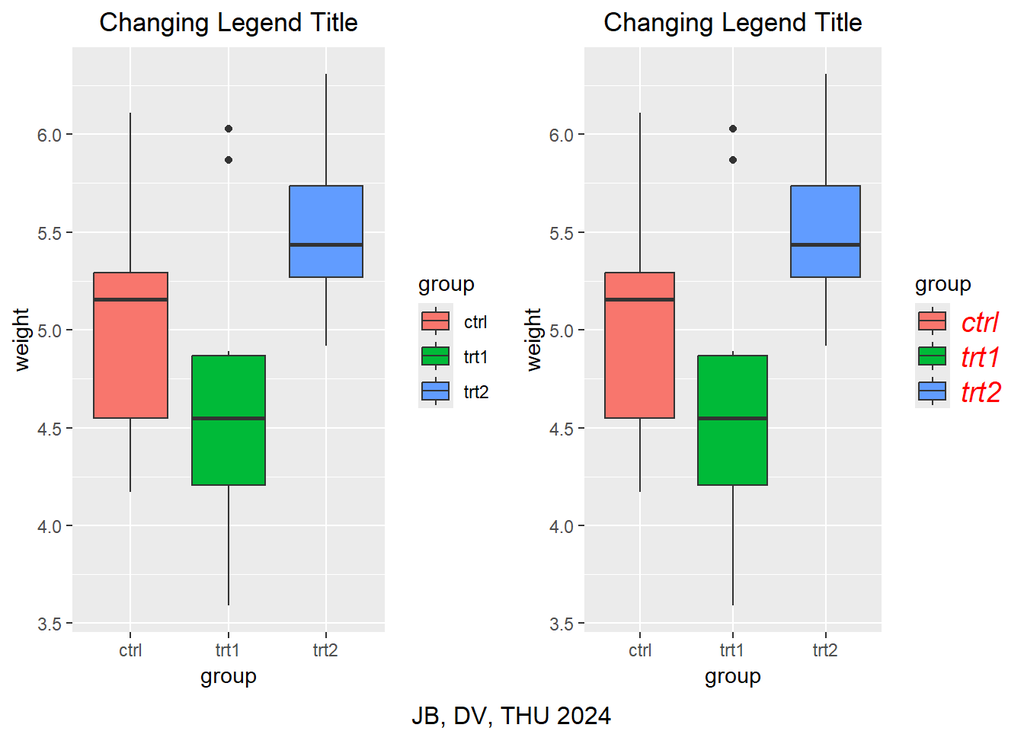

```r
p1 <- ggplot(PlantGrowth, aes(x = group, y = weight, fill = group)) +
  geom_boxplot() +
  ggtitle('Changing Legend Title') +
  theme(plot.title = element_text(hjust=0.5))

p2 <- p1 + theme(legend.text = element_text(face = 'italic',
                                             family = 'Times',
                                             color = 'red',
                                             size = 14))
grid.arrange(p1, p2, ncol = 2, bottom = 'JB, DV, THU 2024')
```

# 17 Legend with Multiple Variables

To add multiple variables in a chart, we can use add `aes` in `ggplot` to plot the dataset of `heightweight` and use `aes(size = weightLb)` to represent another variable that changed the size of the point accordingly

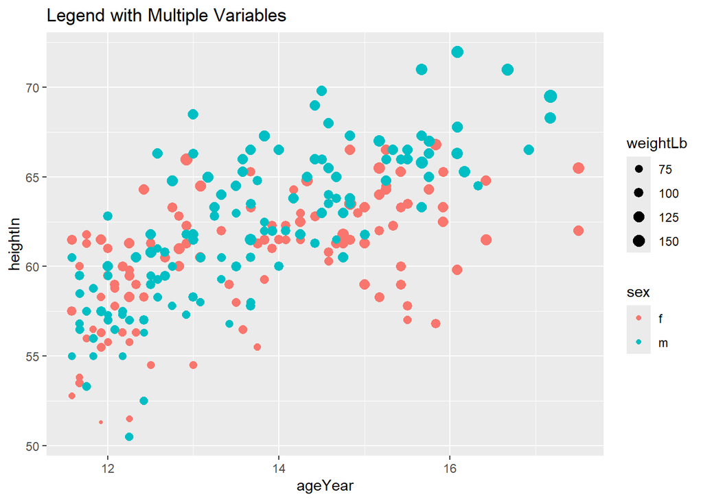

```r
library(gcookbook)
ggplot(heightweight, aes(x = ageYear, y = heightIn, colour = sex)) +
  geom_point(aes(size = weightLb)) +
  scale_size_continuous(range = c(1, 4)) +
  ggtitle('Legend with Multiple Variables')
```

# 18 Resize the Point

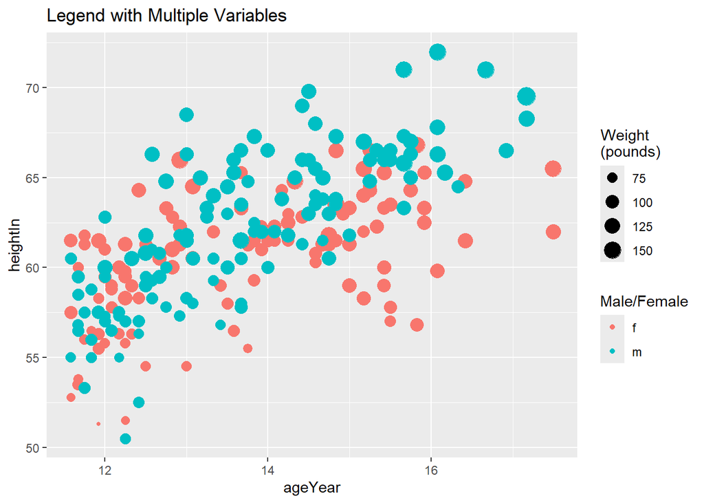

```r
library(gcookbook)
ggplot(heightweight, aes(x = ageYear, y = heightIn, colour = sex)) +
  geom_point(aes(size = weightLb)) +
  labs(colour = "Male/Female", size = "Weight\n(pounds)") +
  ggtitle('Legend with Multiple Variables')
```

# 19 Change Legend Title

In the chart with multiple variable, the `color` represent `Male` or `Female` and the `size` represent the `Weight`.

In order to change the Legend Title, we use `labs` line and change the name by using of the `color` variable `colour = "Male/Female"` and `size` variable by adding `size = "Weight\n(pounds)"`

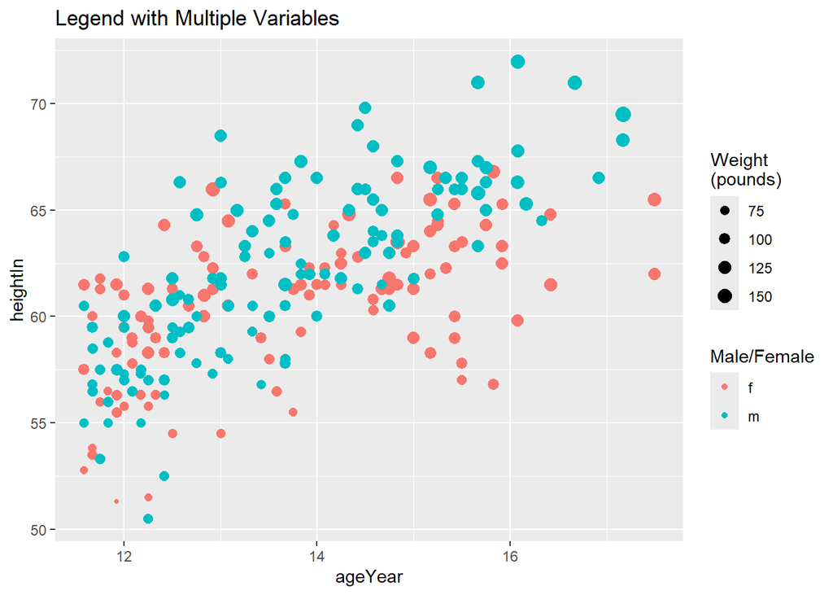

```r
library(gcookbook)
ggplot(heightweight, aes(x = ageYear, y = heightIn, colour = sex)) +
  geom_point(aes(size = weightLb)) +
  scale_size_continuous(range = c(1, 4)) +
  labs(colour = "Male/Female", size = "Weight\n(pounds)") +
  ggtitle('Legend with Multiple Variables')
```

# 20 Change Labels in Legend

`scale_color_discrete(labels = c('Female','Male')`: Using the `scale_color_discrete` we can change the `labels` in the `legend` to `Female` and `Male`

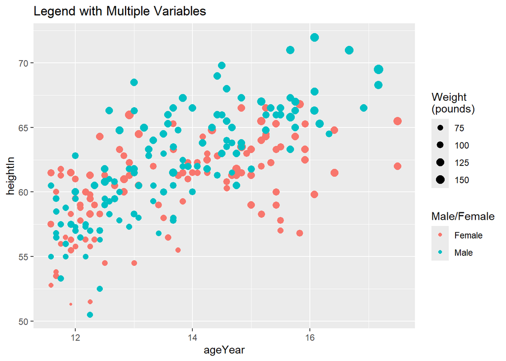

```r
library(gcookbook)
ggplot(heightweight, aes(x = ageYear, y = heightIn, colour = sex)) +
  geom_point(aes(size = weightLb)) +
  scale_size_continuous(range = c(1, 4)) +
  labs(colour = "Male/Female", size = "Weight\n(pounds)") +
  scale_color_discrete(labels = c('Female','Male')) +
  ggtitle('Legend with Multiple Variables')
```